# Lab 9: Data Simulation Exploration

Author

Amir Sepasian

```r
library(gt)
library(kableExtra)
library(knitr)
library(tidyverse)
```

## Random Babies Simulation

Perhaps you have seen the [Random Babies applet](https://www.rossmanchance.com/applets/2021/randombabies/RandomBabies.html)? Suppose one night at a hospital four babies are born. The hospital is not very organized and looses track of which baby belongs to each parent(s), so they decide to return the babies to parents at random. Here, we are interested in the number of babies that are correctly returned to their respective parent(s).

**1. Simulate the distribution of the number of babies that are correctly returned. Use 10,000 simulations.**

**Tip**

Write a function to accomplish one simulation, then use `map_int()` to run 10,000 simulations.

Keep in mind that your function needs to output a single number (not data frame) for it to be compatible with `map_int()`!

```r
randomBabies <- function(nBabies = 4){

  shuff_babies <- sample(1:nBabies)
  return(sum(1:nBabies == shuff_babies))

}


results <- map_int(.x = 1:10000,
                   .f = ~ randomBabies())
```

**2. Create a table displaying the proportion of simulations where 0, 1, 2, 3, and 4 babies were given to their correct parent(s).** Hint: A `pivot_wider()` will be helpful here!

**Tip**

The output of your `map_int()` is a vector, but to make a nice table (and plot) you need this to be a data frame! Luckily, the `enframe()` function does just that–it converts a vector to a data frame.

```r
babyData <- enframe(results,
        name = 'simulation_number',
        value = 'ncorrect')


babyData |>
  count(ncorrect) |>
  mutate(proportions = n / sum(n)) |>
  select(ncorrect, proportions) |>
  pivot_wider(names_from = ncorrect,
              values_from = proportions) |>
  gt() |>

  tab_header(title = 'Proportion of Simulations for Correctly Returned Babies') |>
  cols_label(`0` = '0 Babies',
             `1` = '1 Baby',
             `2` = '2 Babies',
             `4` = '4 Babies') |>

   tab_options(table.font.size = 12,
               table.font.names = 'Georgia')
```

Proportion of Simulations for Correctly Returned Babies

| 0 Babies | 1 Baby | 2 Babies | 4 Babies |
| --- | --- | --- | --- |
| 0.3784 | 0.3349 | 0.244 | 0.0427 |

**3. Now create a barplot showing the proportion of simulations where 0, 1, 2, 3, and 4 babies were given to their correct parent(s).**

**Tip**

You may find the following code helpful:

```r
geom_bar(mapping = aes(y = after_stat(count) / sum(after_stat(count))
                       )
         )
```

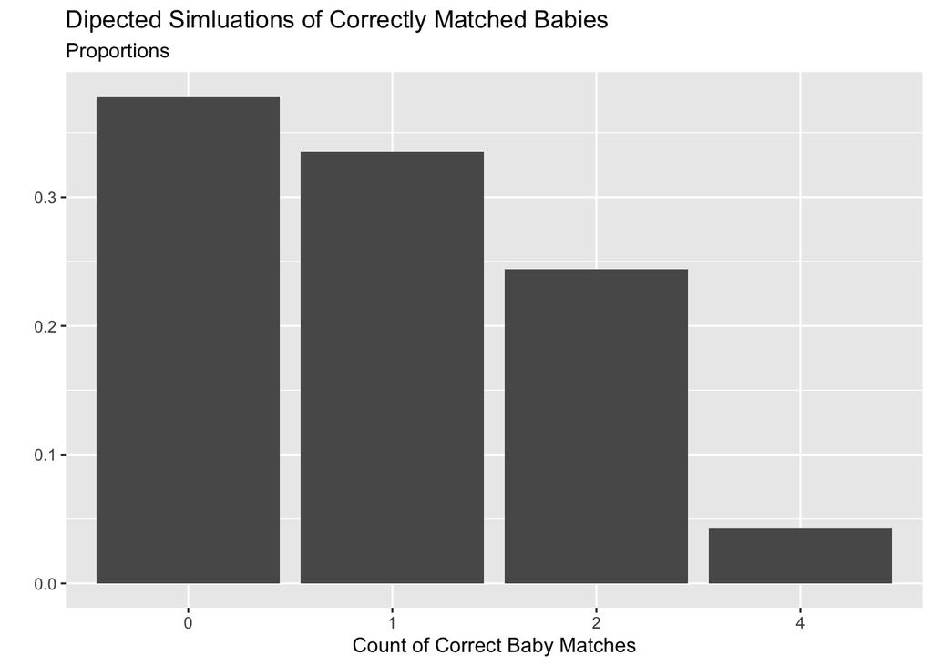

```r
enframe(results, name = 'simulation_number', value = 'ncorrect') |>
  ggplot(aes(x = as.factor(ncorrect)
             )
         ) +
  geom_bar(mapping = aes(y = after_stat(count) / sum(after_stat(count))
                       )
         ) +
  labs(x = 'Count of Correct Baby Matches',
       y = '',
       title = 'Dipected Simluations of Correctly Matched Babies',
       subtitle = 'Proportions')
```